# HEAPO – Data Filtration & Exploratory Data Analysis

2026-03-14

# 1 Data Filtration

## 1.1 Step 1: Filter Time Window

The time window **2022-01-01 to 2024-02-29** was chosen because:

- Only 17 households have complete coverage over the full period (2019–2024), making a full-period subset infeasible.
- From 2022 onwards, 403 households have ≥95% coverage, forming a large and representative pool.
- The window covers two full calendar years plus two months, capturing all seasonal cycles at least twice (critical for heating-related modelling).

```
## Rows after time filter: 555239
```

```
## Households in window:   845
```

```
## Days in window:         790
```

## 1.2 Step 2: Identify Eligible Households (≥95% Coverage)

A household is considered *eligible* if it reported data on at least 95% of the days in the time window. This threshold ensures complete seasonal coverage while tolerating minor gaps (e.g., a few missing days due to meter downtime).

```
## Eligible households (>=95% coverage): 401
```

> **Finding:** 401 households meet the ≥95% coverage threshold in the 2022–2024 window, consistent with the quality report’s finding of 403 eligible households.

## 1.3 Step 3: Random Sample of Households (Max. 100,000 Rows)

To stay within the 100,000 observation limit, eligible households are randomly shuffled and added cumulatively until the row limit is reached. Each eligible household contributes approximately 788 days, so roughly 126 households fit within the limit.

```
## Selected households: 127
```

```
## Observations:        99838
```

```
## Date range:          2022-01-01 to 2024-02-29
```

## 1.4 Step 4: Derive Response Variables

Two derived response variables are added for use in GLM Binomial and other methods:

- **`high_consumption`**: 1 if `kWh_total` exceeds the dataset-wide median, 0 otherwise (used as binary response in GLM Binomial).
- **`log_kWh_total`**: natural log of `kWh_total` (mandatory for LM, as `kWh_total` is an amount variable with right-skewed distribution).

```
## Median kWh_total used for threshold: 20.98
```

```
## high_consumption = 1: 49914 ( 50 %)
```

## 1.5 Step 5: Save Final Modelling Dataset

```
## Saved: data_processed/heapo/heapo_modelling.rds/.csv
```

## 1.6 Filtration Summary

Filtration steps overview

| Step | Households | Observations |
| --- | --- | --- |
| 0 – Full daily dataset | 1205 | 845749 |
| 1 – After time window filter (2022-01-01 to 2024-02-29) | 845 | 555239 |
| 2 – Eligible households (>=95% coverage) | 401 | NA |
| 3 – Random sample (n = 127, max 100k rows) | 127 | NA |
| Final modelling dataset | 127 | 99838 |

# 2 Exploratory Data Analysis

The EDA is performed on the **final modelling dataset** (`heapo_model`: 127 households, 99,838 observations, 2022–2024).

## 2.1 Response Variable: kWh_total

### 2.1.1 Distribution

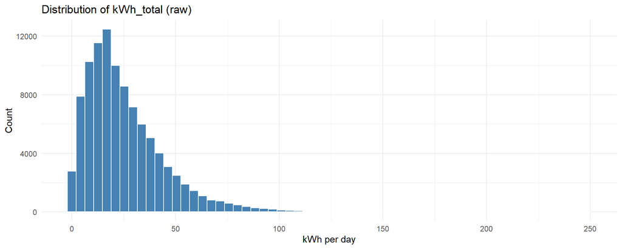

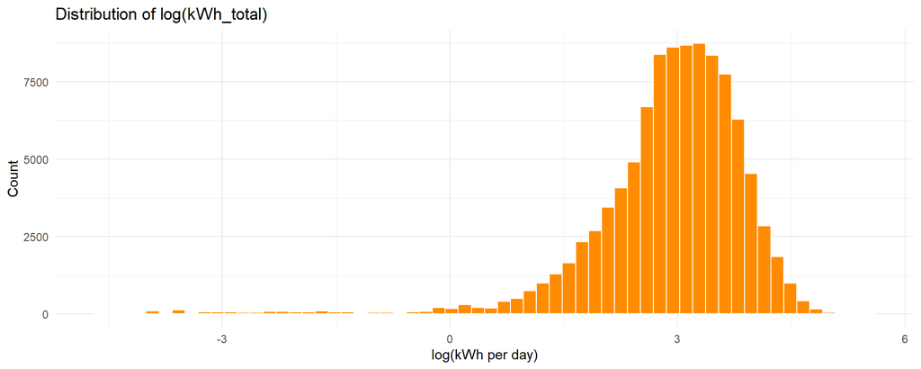

> **Interpretation:** Raw `kWh_total` is strongly right-skewed: a small number of days show very high consumption (cold winter peaks). After log-transformation, the distribution is approximately normal. This confirms that **`log(kWh_total)` must be used as the response in Linear Models**.

### 2.1.2 Summary Statistics

Summary statistics: kWh_total

| Min | Q1 | Median | Mean | Q3 | Max | SD |
| --- | --- | --- | --- | --- | --- | --- |
| 0.01 | 12.13 | 20.98 | 25.49 | 34.5 | 248.27 | 18.99 |

## 2.2 Temporal Patterns

### 2.2.1 Monthly Consumption

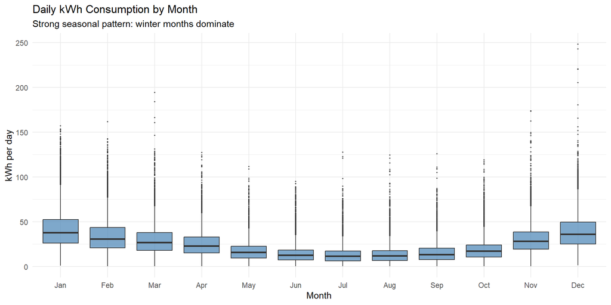

### 2.2.2 Weekday vs. Weekend

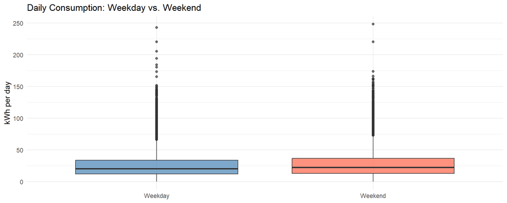

> **Interpretation:** Weekend consumption is slightly higher than weekday consumption on average, consistent with occupants being home more during weekends. However, the difference is modest relative to the seasonal signal, as heating demand is the primary driver of variation.

### 2.2.3 Annual Trend

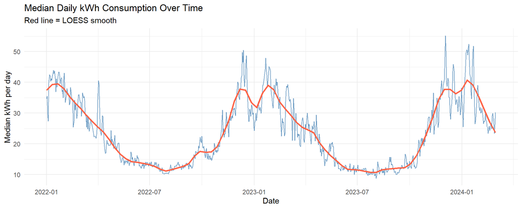

> **Interpretation:** The time series confirms the seasonal cycle across two full years. Consumption peaks in January/February and drops sharply in summer. The amplitude and shape of the two visible cycles (2022 and 2023) are broadly similar, suggesting no major structural break in the data over this period.

## 2.3 Weather Relationships

### 2.3.1 Temperature vs. Consumption

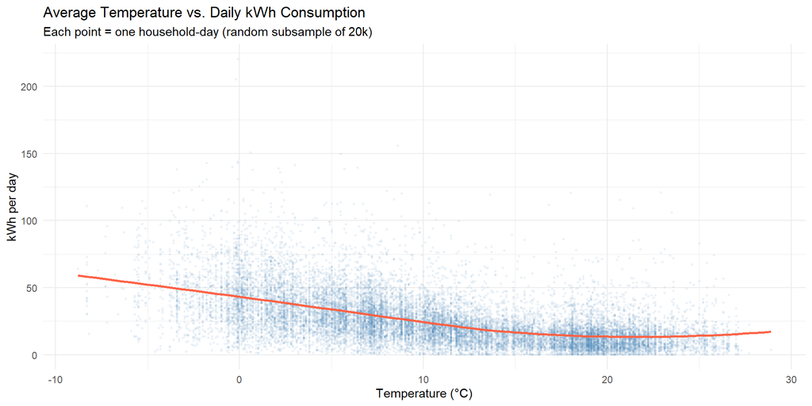

> **Interpretation:** There is a strong non-linear negative relationship between temperature and consumption. Consumption rises sharply below roughly 15°C (the typical heating threshold) and levels off above it. This non-linearity justifies using GAM (which can capture this curve) over a simple linear model for temperature. Note the wide scatter at low temperatures, reflecting household-level heterogeneity.

### 2.3.2 Heating Degree Days vs. Consumption

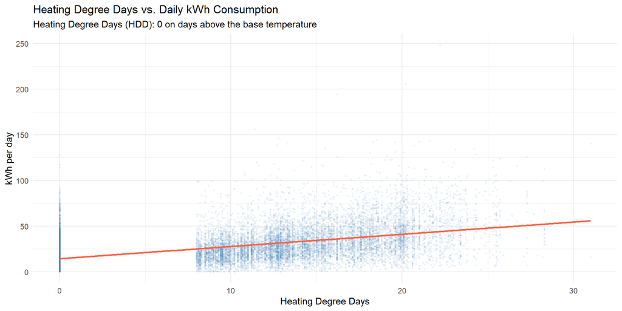

## 2.4 Household-Level Variation

### 2.4.1 Consumption by Building Type

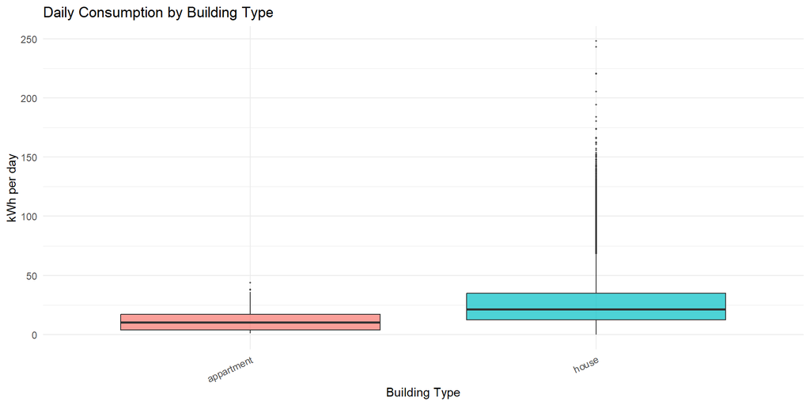

> **Interpretation:** Building type is associated with notable differences in median consumption. Larger or older building types (e.g., detached houses) tend to show higher and more variable consumption, reflecting differences in insulated floor area and construction era. This confirms `building_type` as a relevant predictor.

### 2.4.2 Consumption by Heat Pump Type

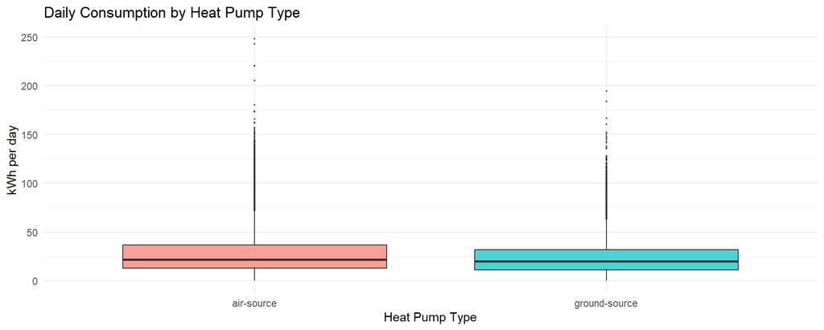

> **Interpretation:** The HEAPO dataset distinguishes two main heat pump types: **air-source** (extracts heat from outdoor air) and **ground/water-source** (extracts heat from the ground or groundwater). Air-source heat pumps are less efficient at low outdoor temperatures because the temperature difference between the heat source and the heating circuit increases, requiring more electrical work. This efficiency is measured by the **Coefficient of Performance (COP)**: the ratio of heat delivered to electricity consumed. A COP of 3 means 3 kWh of heat per 1 kWh of electricity. Ground-source heat pumps maintain a more stable COP year-round because ground temperatures remain relatively constant. Any consumption difference visible here may be partially confounded by building size, insulation, and climate zone.

### 2.4.3 Living Area vs. Consumption

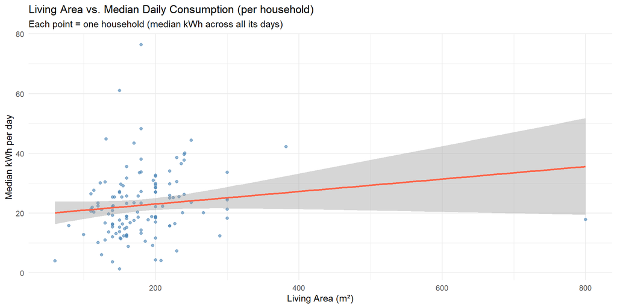

> **Interpretation:** Larger living areas are associated with higher median consumption at the household level. The relationship is approximately linear, supporting inclusion of `living_area` as a continuous predictor. There is notable scatter: households with similar floor area can differ substantially in consumption, likely due to insulation quality, heat pump type, and occupant behaviour.

## 2.5 Categorical Predictors

### 2.5.1 Weather Region Distribution

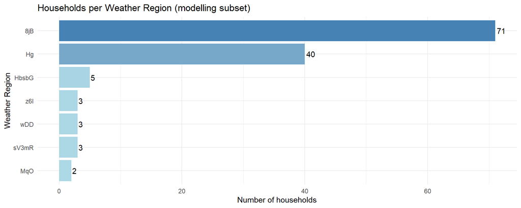

> **Interpretation:** The sampled households are distributed across multiple weather regions. The distribution reflects the original dataset’s geographic composition in the canton of Zurich, Switzerland. Some regions have fewer households, so the categorical predictor `weather_region` may need grouping or regularisation in certain models (e.g., SVM).

### 2.5.2 Binary Predictors Overview

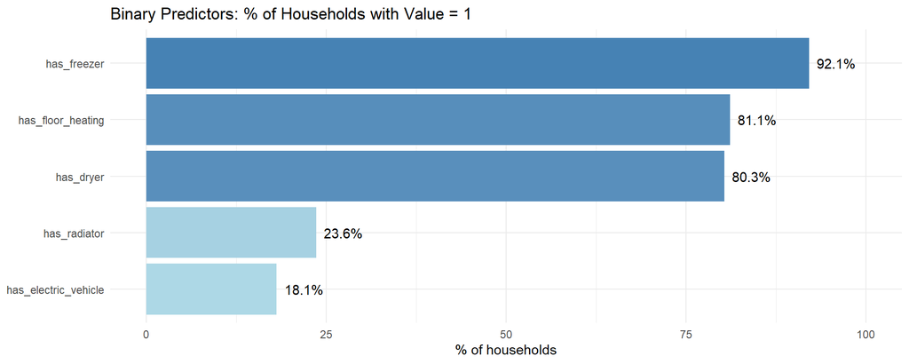

> **Interpretation:** Floor heating (radiant underfloor heating) distributes heat via pipes embedded in the floor and operates at lower supply temperatures (typically 30-40°C) compared to radiators (60-80°C). Heat pumps are more efficient at lower supply temperatures because the temperature lift (the difference between source and output) is smaller, resulting in a higher COP. Households with floor heating therefore tend to use electricity more efficiently for the same amount of heat delivered. Variables with very low prevalence (e.g., below 5%) may have limited predictive power or require careful handling in models.

## 2.6 Correlation Analysis

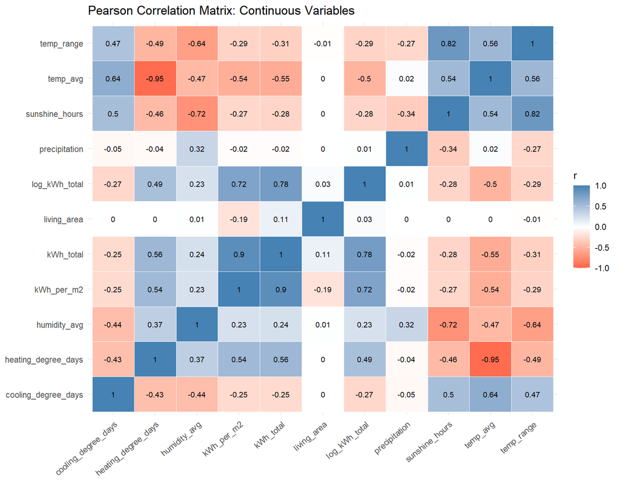

## 2.7 Binary Response: high_consumption

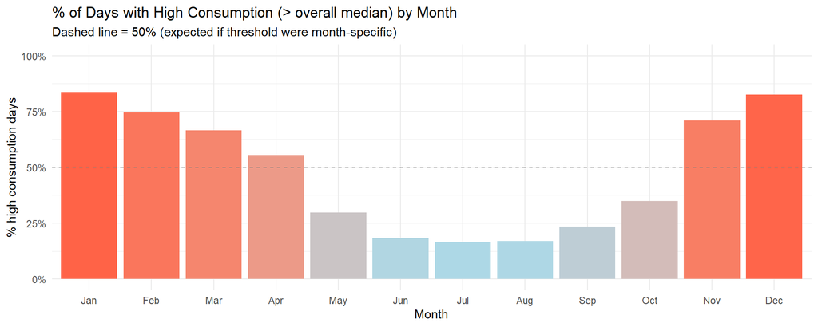

# 3 Summary

Final modelling dataset: summary

| Item | Value |
| --- | --- |
| Final dataset | heapo_modelling.rds / .csv |
| Households | 127 |
| Observations | 99,838 |
| Time window | 2022-01-01 to 2024-02-29 |
| Eligibility criterion | >=95% data coverage in window |
| Sampling | Random sample of 127 from 401 eligible (seed = 42, max 100k rows) |
| Primary response (LM/GAM) | log(kWh_total) |
| Binary response (GLM Binomial) | high_consumption (kWh_total > global median) |
| Count response (GLM Poisson) | n_residents |
| Key predictors | heating_degree_days, temp_avg, living_area, building_type, heatpump_type |

*Report generated on 2026-03-14 using R 4.5.1.*